# RaMP-DB 3.x Vignette

### Retrieve Pathways From Input Analyte(s)

It is oftentimes useful to get a sense of what pathways are represented in a dataset (this is particularly true for metabolomics, where coverage of metabolites varies depending on what platform is used). In other cases, one may be interested in exploring one or several metabolites to see what pathways they are arepresented in.

Note that it is always preferable to utilize IDs rather then common names. When entering IDs, prepend each ID with the database of origin followed by a colon, for example kegg:C02712, hmdb:HMDB04824, etc.. It is possible to input IDs using multiple different sources. RaMP currently supports the following ID types (that should be prepended):

```r
  metabprefixes <- getPrefixesFromAnalytes(db = rampDB, "metabolite")
  geneprefixes <- getPrefixesFromAnalytes(db = rampDB, "gene")

  datatable(rbind(metabprefixes, geneprefixes))
```

|  | analyteType | idTypes |
| --- | --- | --- |
| 1 | Metabolites | hmdb, chebi, chemspider, kegg, pubchem, CAS, wikidata, LIPIDMAPS, lipidbank, swisslipids, plantfa, kegg_glycan, rhea-comp, polymer |
| 2 | Genes/Proteins | hmdb, uniprot, gene_symbol, entrez, ensembl, wikidata, ncbiprotein, EN, brenda, chebi |

```r
pathwaydfids <- getPathwayFromAnalyte(db = rampDB, c("ensembl:ENSG00000135679", "hmdb:HMDB0000064",
        "hmdb:HMDB0000148", "ensembl:ENSG00000141510"))
```

```
## [1] "Starting getPathwayFromAnalyte()"
## [1] "Working on ID List..."
## [1] "finished getPathwayFromAnalyte()"
## [1] "Found 866 associated pathways."
```

```r
datatable(pathwaydfids)
```

|  | pathwayName | pathwaySource | pathwayId | inputId | commonName |
| --- | --- | --- | --- | --- | --- |
| 1 | 10q11.21q11.23 copy number variation syndrome | wiki | WP5352 | ensembl:ENSG00000135679 | MDM2 |
| 2 | 11p11.2 copy number variation syndrome | wiki | WP5348 | ensembl:ENSG00000141510 | TP53 |
| 3 | 15q13.3 copy number variation syndrome | wiki | WP4942 | hmdb:HMDB0000148 | L-Glutamic acid,Glutamate |
| 4 | 16p11.2 proximal deletion syndrome | wiki | WP4949 | ensembl:ENSG00000141510 | TP53 |
| 5 | 2-LTR circle formation | reactome | R-HSA-164843 | ensembl:ENSG00000135679 | MDM2 |
| 6 | 22q11.2 copy number variation syndrome | wiki | WP4657 | ensembl:ENSG00000141510 | TP53 |
| 7 | 22q11.2 copy number variation syndrome | wiki | WP4657 | hmdb:HMDB0000148 | L-Glutamic acid,Glutamate |
| 8 | 2q37 copy number variation syndrome | wiki | WP5224 | ensembl:ENSG00000141510 | TP53 |
| 9 | 7q11.23 copy number variation syndrome | wiki | WP4932 | hmdb:HMDB0000148 | L-Glutamic acid,Glutamate |
| 10 | A network map of Macrophage-stimulating protein (MSP) signaling | wiki | WP5353 | ensembl:ENSG00000141510 | TP53 |

[output cut: 856 more lines]

Note that each row returns a pathway attributed to one of the input analytes. To retrieve the number of unique pathways returned for all analytes or each analyte, try the following:

```r
print(paste("Number of Unique Pathways Returned for All Analytes:",
            length(unique(pathwaydfids$pathwayId))))
```

```
## [1] "Number of Unique Pathways Returned for All Analytes: 722"
```

```r
lapply(unique(pathwaydfids$commonName), function(x) {
        (paste("Number of Unique Pathways Returned for",x,":",
                length(unique(pathwaydfids[which(pathwaydfids$commonName==x),]$pathwayId))))})
```

```
## [[1]]
## [1] "Number of Unique Pathways Returned for MDM2 : 402"
##
## [[2]]
## [1] "Number of Unique Pathways Returned for TP53 : 214"
##
## [[3]]
## [1] "Number of Unique Pathways Returned for L-Glutamic acid,Glutamate : 238"
##
## [[4]]
## [1] "Number of Unique Pathways Returned for Creatine : 12"
```

### Retrieve Metabolites from Metabolite Ontologies

Conversely, the user can retrieve the metabolites that are associated with a specific ontology or vector of ontologies. We can accomplish this using the function getMetaFromOnto(). It should be noted that it does not matter which ontology the metabolites are from. The function will return all metabolites associated with all the ontologies specified by the user.

```r
ontologies.of.interest <- c("Colon", "Liver", "Lung")

new.metabolites <- RaMP::getMetaFromOnto(db = rampDB, ontology = ontologies.of.interest)
```

```
## [1] "Retreiving Metabolites for input ontology terms."
## [1] "Found 3 ontology term matches."
## [1] "Found 1482 metabolites associated with the input ontology terms."
## [1] "Finished getting metabolies from ontology terms."
```

```r
datatable(head(new.metabolites, n=10))
```

|  | ontologyTerm | ontologyCategory | metNames | metIds |
| --- | --- | --- | --- | --- |
| 1 | Colon | Organ and components | Methanethiol | hmdb:HMDB0003227,chebi:16007,chemspider:855,kegg:C00409,pubchem:878,CAS:74-93-1,hmdb:HMDB03227 |
| 2 | Colon | Organ and components | Hydrogen sulfide,H2S,hydrosulfide | hmdb:HMDB0003276,chebi:16136,chemspider:391,kegg:C00283,pubchem:402,CAS:7783-06-4,hmdb:HMDB03276,wikidata:Q170591,chebi:29919,chemspider:4224877,pubchem:5047209,wikidata:Q3771739 |
| 3 | Liver | Organ and components | 4-Pyridoxic acid,PDXate,4-pyridoxate | hmdb:HMDB0000017,chebi:17405,chemspider:6467,kegg:C00847,pubchem:6723,CAS:82-82-6,hmdb:HMDB00017,wikidata:Q27102382,chebi:30959 |
| 4 | Liver | Organ and components | Betaine,glycine betaine,BET | hmdb:HMDB0000043,chebi:41139,chemspider:243,pubchem:248,CAS:6915-17-9,hmdb:HMDB00043,hmdb:HMDB0059606,hmdb:HMDB59606,chebi:17750,kegg:C00719,CAS:107-43-7,wikidata:Q10860583,chemspider:242,pubchem:247 |
| 5 | Liver | Organ and components | Bilirubin,BIL,(4E,15Z)-Bilirubin,(4E,15E)-Bilirubin,bilirubin(2-),bilirubin IXalpha | hmdb:HMDB0000054,chebi:16990,chemspider:4444055,kegg:C00486,pubchem:5280352,CAS:635-65-4,hmdb:HMDB00054,wikidata:Q104219,hmdb:HMDB0000488,chebi:72719,chemspider:13628097,pubchem:21252250,CAS:69853-43-… |
| 6 | Liver | Organ and components | Adenosine 3',5'-diphosphate,PAP,adenosine 3',5'-bisphosphate,adenosine 3',5'-bismonophosphate(4-) | hmdb:HMDB0000061,chebi:17985,chemspider:140102,kegg:C00054,pubchem:159296,CAS:1053-73-2,hmdb:HMDB0001468,hmdb:HMDB00061,hmdb:HMDB01468,wikidata:Q2825485,chebi:58343,chemspider:19951095,pubchem:2361519… |
| 7 | Liver | Organ and components | Cortisol,CORT,Urocortisone,ST 21:3;O5,11-Epicortisol | hmdb:HMDB0000063,chebi:17650,kegg:C00735,pubchem:5754,CAS:50-23-7,hmdb:HMDB00063,hmdb:HMDB0014879,hmdb:HMDB14879,wikidata:Q190875,LIPIDMAPS:LMST02030001,chemspider:5551,wikidata:Q26981430,chebi:180955… |
| 8 | Liver | Organ and components | Epinephrine,ADR,Oxidized-adrenal-ferredoxin,(R)-adrenaline(1+),(R)-adrenaline | hmdb:HMDB0000068,chebi:28918,chemspider:5611,kegg:C00788,pubchem:5816,CAS:51-43-4,hmdb:HMDB0000615,hmdb:HMDB00068,hmdb:HMDB00615,wikidata:Q132621,hmdb:HMDB0062515,chebi:33568,chemspider:815,pubchem:83… |
| 9 | Liver | Organ and components | Dihydrouracil,5,6-dihydrouracil,DHU | hmdb:HMDB0000076,chebi:15901,chemspider:629,kegg:C00429,pubchem:649,CAS:504-07-4,hmdb:HMDB00076,wikidata:Q409340 |
| 10 | Liver | Organ and components | Choline,Cho | hmdb:HMDB0000097,chebi:15354,chemspider:299,kegg:C00114,pubchem:305,CAS:62-49-7,hmdb:HMDB00097,wikidata:Q193166 |

### Retrieve Ontologies from Input Metabolites

To retrieve ontologies that are associated with our metabolites we can use getOntoFromMeta(). This function takes in a vector of metabolites as an input and returns a vector comprised of the ontologies from the user’s defined metabolites.

```r
analytes.of.interest <- c("ensembl:ENSG00000135679", "hmdb:HMDB0000064",
        "hmdb:HMDB0000148", "ensembl:ENSG00000141510")
new.ontologies <- RaMP::getOntoFromMeta(db = rampDB, analytes = analytes.of.interest)
datatable(new.ontologies)
```

|  | Metabolites | sourceId | IDtype | Ontology | HMDBOntologyType |
| --- | --- | --- | --- | --- | --- |
| 1 | L-Glutamic acid | hmdb:HMDB0000148 | hmdb | Saliva | Biofluid and excreta |
| 2 | Glutamate | hmdb:HMDB0000148 | hmdb | Saliva | Biofluid and excreta |
| 3 | L-Glutamic acid | hmdb:HMDB0000148 | hmdb | Adipose tissue | Tissue and substructures |
| 4 | Glutamate | hmdb:HMDB0000148 | hmdb | Adipose tissue | Tissue and substructures |
| 5 | L-Glutamic acid | hmdb:HMDB0000148 | hmdb | Endogenous | Source |
| 6 | Glutamate | hmdb:HMDB0000148 | hmdb | Endogenous | Source |
| 7 | L-Glutamic acid | hmdb:HMDB0000148 | hmdb | Feces | Biofluid and excreta |
| 8 | Glutamate | hmdb:HMDB0000148 | hmdb | Feces | Biofluid and excreta |
| 9 | L-Glutamic acid | hmdb:HMDB0000148 | hmdb | Urine | Biofluid and excreta |
| 10 | Glutamate | hmdb:HMDB0000148 | hmdb | Urine | Biofluid and excreta |

[output cut: 109 more lines]

### Retrieve Analytes Involved in the Same Reaction

The user may want to know what gene transcripts encode enzymes which can catalyze reactions involving metabolites in their experiment. RaMP can return this data to its user.

We can return the gene transcripts using the rampFastCata() function. To use it the user needs to provide a vector of metabolites they are interested in and the connection information for MySQL. The user can also input a vector of protein IDs or gene transcripts to return the metabolites involved in chemical reactions with the input proteins or gene transcript encoded proteins.

```r
#Input Metabolites
analytes.of.interest <- c("ensembl:ENSG00000135679", "hmdb:HMDB0000064",
        "hmdb:HMDB0000148", "ensembl:ENSG00000141510")

new.transcripts <- rampFastCata(db = rampDB, analytes = analytes.of.interest)
```

```
## [1] "Analyte ID-based reaction partner query."
## [1] "Building metabolite to gene relations."
## [1] "Number of met2gene relations: 100"
## [1] "Building gene to metabolite relations."
## [1] "Total Relation Count: 13062"
```

```r
datatable(head(new.transcripts, n=10))
```

|  | query_relation | input_analyte | input_common_names | rxn_partner_common_name | rxn_partner_ids |
| --- | --- | --- | --- | --- | --- |
| 1 | met2gene | hmdb:HMDB0000148 | L-Glutamic acid,Glutamate | BCAT1 | hmdb:HMDBP00301,gene_symbol:BCAT1,uniprot:P54687,entrez:586,ensembl:ENSG00000060982,uniprot:A0A024RAV0,uniprot:A0A087WYF2,uniprot:F5H2F2,uniprot:B3KY27,uniprot:B7Z2M5,uniprot:B7Z5L0,uniprot:F5H5E4,uni… |
| 2 | met2gene | hmdb:HMDB0000148 | L-Glutamic acid,Glutamate | BCAT2 | hmdb:HMDBP00516,gene_symbol:BCAT2,uniprot:O15382,entrez:587,ensembl:ENSG00000105552,uniprot:M0QXF9,uniprot:M0QZ10,uniprot:M0QZP4,uniprot:B3KSI3,uniprot:M0R2K7,uniprot:B2RB87,uniprot:O00269,uniprot:Q96… |
| 3 | met2gene | hmdb:HMDB0000148 | L-Glutamic acid,Glutamate | SLC16A1 | hmdb:HMDBP01111,gene_symbol:SLC16A1,uniprot:P53985,entrez:6566,ensembl:ENSG00000155380,uniprot:Q5T8R3,uniprot:Q5T8R4,uniprot:A0A024R0H1,uniprot:Q5T8R5,uniprot:Q49A45,uniprot:Q5T8R6,uniprot:Q9NSJ9 |
| 4 | met2gene | hmdb:HMDB0000148 | L-Glutamic acid,Glutamate | EPRS,EPRS1 | hmdb:HMDBP00567,gene_symbol:EPRS,uniprot:P07814,gene_symbol:EPRS1,entrez:2058,ensembl:ENSG00000136628,uniprot:V9GZ76,uniprot:V9GYZ6,uniprot:A0AVA9,uniprot:B9EGH3,uniprot:Q05BP6,uniprot:Q05DF8,uniprot:… |
| 5 | met2gene | hmdb:HMDB0000148 | L-Glutamic acid,Glutamate | ASNS | hmdb:HMDBP00583,gene_symbol:ASNS,uniprot:P08243,entrez:440,ensembl:ENSG00000070669,uniprot:C9JT45,uniprot:C9J605,uniprot:C9J057,uniprot:C9JLA3,uniprot:F8WEJ5,uniprot:C9JM09,uniprot:C9JLN6,uniprot:A4D1… |
| 6 | met2gene | hmdb:HMDB0000148 | L-Glutamic acid,Glutamate | GMPS | hmdb:HMDBP00592,gene_symbol:GMPS,uniprot:P49915,entrez:8833,ensembl:ENSG00000163655,uniprot:A0A140VJK6,uniprot:A8K639,uniprot:B4DXV7,uniprot:F8W720 |
| 7 | met2gene | hmdb:HMDB0000148 | L-Glutamic acid,Glutamate | NADSYN1 | hmdb:HMDBP03241,gene_symbol:NADSYN1,uniprot:Q6IA69,entrez:55191,ensembl:ENSG00000172890,uniprot:H0YCF9,uniprot:A0A0B4J216,uniprot:H0YCQ6,uniprot:E9PND0,uniprot:E9PNF5,uniprot:E9PKY6,uniprot:H0YED2,uni… |
| 8 | met2gene | hmdb:HMDB0000148 | L-Glutamic acid,Glutamate | EARS2 | hmdb:HMDBP07382,gene_symbol:EARS2,uniprot:Q5JPH6,entrez:124454,ensembl:ENSG00000103356,uniprot:I3L166,uniprot:H3BQI0,uniprot:H3BQP8,uniprot:H3BPY3,uniprot:H3BTB7,uniprot:B3KTT2,uniprot:D3DWF1,uniprot:… |
| 9 | met2gene | hmdb:HMDB0000148 | L-Glutamic acid,Glutamate | CCBL1,KYAT1 | hmdb:HMDBP00464,gene_symbol:CCBL1,uniprot:Q16773,gene_symbol:KYAT1,entrez:883,ensembl:ENSG00000171097,uniprot:A8K563,uniprot:B7Z4W5,uniprot:Q5T277,uniprot:Q5T278,uniprot:Q5T276,uniprot:Q5T275,uniprot:… |
| 10 | met2gene | hmdb:HMDB0000148 | L-Glutamic acid,Glutamate | GLUD2 | hmdb:HMDBP00666,gene_symbol:GLUD2,uniprot:P49448,entrez:2747,ensembl:ENSG00000182890,uniprot:A0A140VK14,uniprot:B2R8G0,uniprot:Q9UDQ4 |

```r
#Input Proteins
proteins.of.interest <- c("uniprot:094808", "uniprot:Q99259")

new.metabolites <- rampFastCata(db = rampDB, analytes = proteins.of.interest)
```

```
## [1] "Analyte ID-based reaction partner query."
## [1] "Building metabolite to gene relations."
## [1] "Number of met2gene relations: 0"
## [1] "Building gene to metabolite relations."
## [1] "Total Relation Count: 12"
```

```r
datatable(head(new.metabolites, n=10))
```

|  | query_relation | input_analyte | input_common_names | rxn_partner_common_name | rxn_partner_ids |
| --- | --- | --- | --- | --- | --- |
| 1 | gene2met | uniprot:Q99259 | GAD1 | beta-Alanine,b-Ala,beta-alanine zwitterion | hmdb:HMDB0000056,chebi:16958,chemspider:234,kegg:C00099,pubchem:239,CAS:107-95-9,hmdb:HMDB00056,wikidata:Q310919,chebi:57966,wikidata:Q106345620 |
| 2 | gene2met | uniprot:Q99259 | GAD1 | L-Aspartic acid,Asp,Aspartate,D-Aspartic acid,D-Asp,D-aspartate,L-aspartate(1-),L-Asp,L-aspartate,Aspartic acid | hmdb:HMDB0000191,chebi:17053,chemspider:5745,kegg:C00049,pubchem:5960,CAS:56-84-8,hmdb:HMDB00191,wikidata:Q178450,hmdb:HMDB0006483,chebi:17364,chemspider:75697,kegg:C00402,pubchem:83887,CAS:1783-96-6,… |
| 3 | gene2met | uniprot:Q99259 | GAD1 | Taurine,TAU,taurine zwitterion | hmdb:HMDB0000251,chebi:15891,chemspider:1091,kegg:C00245,pubchem:1123,CAS:107-35-7,hmdb:HMDB00251,wikidata:Q207051,chebi:507393,wikidata:Q106345481 |
| 4 | gene2met | uniprot:Q99259 | GAD1 | Ureidosuccinic acid,N-Carbamoyl-L-aspartate,N-carbamoyl-L-aspartate(2-),Carbamoylaspartate | hmdb:HMDB0000828,chebi:15859,chemspider:84022,kegg:C00438,pubchem:93072,CAS:13184-27-5,hmdb:HMDB00828,wikidata:Q2823324,wikidata:Q55177068,chebi:32814,chemspider:4573859,pubchem:5460257,wikidata:Q2710… |
| 5 | gene2met | uniprot:Q99259 | GAD1 | Famotidine | hmdb:HMDB0001919,chebi:4975,chemspider:3208,pubchem:3325,CAS:76824-35-6,hmdb:HMDB01919 |
| 6 | gene2met | uniprot:Q99259 | GAD1 | Carbon dioxide,CO2 | hmdb:HMDB0001967,chebi:16526,chemspider:274,kegg:C00011,pubchem:280,CAS:124-38-9,hmdb:HMDB01967,wikidata:Q1997 |
| 7 | gene2met | uniprot:Q99259 | GAD1 | Cysteic acid,(R)-cysteate,L-cysteic acid,CYSA,L-cysteate | hmdb:HMDB0002757,hmdb:HMDB0303991,chebi:21260,chemspider:23942,kegg:C00506,pubchem:25701,CAS:498-40-8,hmdb:HMDB02757,chebi:17285,chemspider:65718,wikidata:Q2823250,pubchem:72886,wikidata:Q29743881,che… |
| 8 | gene2met | uniprot:Q99259 | GAD1 | L-Glutamic acid,Glutamate,L-Glutamate,Glutamic acid,D-Glutamic acid,DGL,DL-Glutamate,L-glutamate(1-),L-Glu,D-glutamate | hmdb:HMDB0000148,chebi:16015,kegg:C00025,pubchem:33032,CAS:56-86-0,hmdb:HMDB00148,chemspider:30572,wikidata:Q26995161,hmdb:HMDB0003339,chebi:15966,chemspider:21814,kegg:C00217,pubchem:23327,CAS:6893-2… |
| 9 | gene2met | uniprot:Q99259 | GAD1 | Hypotaurine,hypotaurine zwitterion | hmdb:HMDB0000965,chebi:16668,chemspider:96959,kegg:C00519,pubchem:107812,CAS:300-84-5,hmdb:HMDB00965,wikidata:Q3138539,chebi:57853,wikidata:Q106345623 |
| 10 | gene2met | uniprot:Q99259 | GAD1 | Pyridoxal 5'-phosphate,PLP,pyridoxal 5'-phosphate(2-) | hmdb:HMDB0001491,chebi:18405,chemspider:1022,kegg:C00018,pubchem:1051,CAS:54-47-7,hmdb:HMDB01491,wikidata:Q418957,chebi:597326 |

RaMP has a built in function which is able to generate networks from the transcript data. This function is named plotCataNetwork(). This function uses the dataframe created by rampFastCata() as an input. These plots are completely interactive.

```r
plotCataNetwork(head(new.transcripts, n=100))
```

[interactive chart not shown]

### Retrieve Chemical Classes from Input Metabolites

RaMP incorporates Classfire and lipidMAPS classes. The function chemicalClassSurvey() function takes as input a vector of metabolites and outputs the classes associated with each metabolite input.

```r
metabolites.of.interest = c('hmdb:HMDB0000056','hmdb:HMDB0000439','hmdb:HMDB0000479','hmdb:HMDB0000532',
                            'hmdb:HMDB0001015','hmdb:HMDB0001138','hmdb:HMDB0029159','hmdb:HMDB0029412',
                            'hmdb:HMDB0034365','hmdb:HMDB0035227','hmdb:HMDB0007973','hmdb:HMDB0008057',
                            'hmdb:HMDB0011211')
chemical.classes <- chemicalClassSurvey(db = rampDB, mets = metabolites.of.interest)
```

```
## [1] "Starting Chemical Class Survey"
## [1] "...finished metabolite list query..."
## [1] "...finished DB population query..."
## [1] "...collating data..."
## [1] "...creating query efficiency summary..."
## [1] "Finished Chemical Class Survey"
```

```r
metabolite.classes <- as.data.frame(chemical.classes$met_classes)
datatable(metabolite.classes)
```

|  | sourceId | common_names | class_level_name | class_name | source | directIdClassHits |
| --- | --- | --- | --- | --- | --- | --- |
| 1 | hmdb:HMDB0000479 | 3-Methylhistidine | ClassyFire_class | Carboxylic acids and derivatives | hmdb | 2 |
| 2 | hmdb:HMDB0000479 | 3-Methylhistidine | ClassyFire_sub_class | Amino acids, peptides, and analogues | hmdb | 2 |
| 3 | hmdb:HMDB0000479 | 3-Methylhistidine | ClassyFire_super_class | Organic acids and derivatives | hmdb | 2 |
| 4 | hmdb:HMDB0000056 | beta-Alanine | ClassyFire_class | Carboxylic acids and derivatives | hmdb | 1 |
| 5 | hmdb:HMDB0000056 | beta-Alanine | ClassyFire_sub_class | Amino acids, peptides, and analogues | hmdb | 1 |
| 6 | hmdb:HMDB0000056 | beta-Alanine | ClassyFire_super_class | Organic acids and derivatives | hmdb | 1 |
| 7 | hmdb:HMDB0000439 | 2-Furoylglycine | ClassyFire_class | Carboxylic acids and derivatives | hmdb | 1 |
| 8 | hmdb:HMDB0000439 | 2-Furoylglycine | ClassyFire_sub_class | Amino acids, peptides, and analogues | hmdb | 1 |
| 9 | hmdb:HMDB0000439 | 2-Furoylglycine | ClassyFire_super_class | Organic acids and derivatives | hmdb | 1 |
| 10 | hmdb:HMDB0000532 | Acetylglycine | ClassyFire_class | Carboxylic acids and derivatives | hmdb | 1 |

[output cut: 38 more lines]

### Retrieve Chemical Property Information from Input Metabolites

Chemical properties captured by RaMP include SMILES, InChI, InChI-keys, monoisotopic masses, molecular formula, and common name. The getChemicalProperties() function takes as input a vector of metabolites and outputs a list of chemical property information that can easily be converted into a dataframe.

```r
chemical.properties <- getChemicalProperties(db = rampDB, metabolites.of.interest)
```

```
## Starting Chemical Property Query
```

```
## Finished Chemical Property Query
```

```r
chemical.data <- chemical.properties$chem_props
datatable(chemical.data)
```

|  | chem_data_source | chem_source_id | iso_smiles | inchi_key_prefix | inchi_key | inchi | mw | monoisotop_mass | common_name | mol_formula |
| --- | --- | --- | --- | --- | --- | --- | --- | --- | --- | --- |
| 1 | hmdb | hmdb:HMDB0000479 | [H][C@](N)(CC1=CN=CN1C)C(O)=O | JDHILDINMRGULE | JDHILDINMRGULE-LURJTMIESA-N | InChI=1S/C7H11N3O2/c1-10-4-9-3-5(10)2-6(8)7(11)12/h3-4,6H,2,8H2,1H3,(H,11,12)/t6-/m0/s1 | 169.1811 | 169.085126611 | 3-Methylhistidine | C7H11N3O2 |
| 2 | hmdb | hmdb:HMDB0000056 | NCCC(O)=O | UCMIRNVEIXFBKS | UCMIRNVEIXFBKS-UHFFFAOYSA-N | InChI=1S/C3H7NO2/c4-2-1-3(5)6/h1-2,4H2,(H,5,6) | 89.0932 | 89.047678473 | beta-Alanine | C3H7NO2 |
| 3 | hmdb | hmdb:HMDB0000439 | OC(=O)CNC(=O)C1=CC=CO1 | KSPQDMRTZZYQLM | KSPQDMRTZZYQLM-UHFFFAOYSA-N | InChI=1S/C7H7NO4/c9-6(10)4-8-7(11)5-2-1-3-12-5/h1-3H,4H2,(H,8,11)(H,9,10) | 169.1348 | 169.037507717 | 2-Furoylglycine | C7H7NO4 |
| 4 | hmdb | hmdb:HMDB0000532 | CC(=O)NCC(O)=O | OKJIRPAQVSHGFK | OKJIRPAQVSHGFK-UHFFFAOYSA-N | InChI=1S/C4H7NO3/c1-3(6)5-2-4(7)8/h2H2,1H3,(H,5,6)(H,7,8) | 117.1033 | 117.042593095 | Acetylglycine | C4H7NO3 |
| 5 | hmdb | hmdb:HMDB0001015 | CSCC[C@H](NC=O)C(O)=O | PYUSHNKNPOHWEZ | PYUSHNKNPOHWEZ-YFKPBYRVSA-N | InChI=1S/C6H11NO3S/c1-11-3-2-5(6(9)10)7-4-8/h4-5H,2-3H2,1H3,(H,7,8)(H,9,10)/t5-/m0/s1 | 177.221 | 177.045963913 | N-Formyl-L-methionine | C6H11NO3S |
| 6 | hmdb | hmdb:HMDB0001138 | CC(=O)N[C@@H](CCC(O)=O)C(O)=O | RFMMMVDNIPUKGG | RFMMMVDNIPUKGG-YFKPBYRVSA-N | InChI=1S/C7H11NO5/c1-4(9)8-5(7(12)13)2-3-6(10)11/h5H,2-3H2,1H3,(H,8,9)(H,10,11)(H,12,13)/t5-/m0/s1 | 189.1659 | 189.063722467 | N-Acetyl-L-glutamic acid | C7H11NO5 |
| 7 | hmdb | hmdb:HMDB0007973 | [H][C@@](COC(=O)CCCCCCCCCCCCCCC)(COP([O-])(=O)OCC[N+](C)(C)C)OC(=O)CCCCCCC\C=C/C\C=C/CCCCC | JLPULHDHAOZNQI | JLPULHDHAOZNQI-ZTIMHPMXSA-N | InChI=1S/C42H80NO8P/c1-6-8-10-12-14-16-18-20-21-23-25-27-29-31-33-35-42(45)51-40(39-50-52(46,47)49-37-36-43(3,4)5)38-48-41(44)34-32-30-28-26-24-22-19-17-15-13-11-9-7-2/h14,16,20-21,40H,6-13,15,17-19,2… | 758.0603 | 757.562155053 | PC(16:0/18:2(9Z,12Z)) | C42H80NO8P |
| 8 | hmdb | hmdb:HMDB0008057 | CCCCCCCCCCCCCCCCCC(=O)OC[C@]([H])(COP([O-])(=O)OCC[N+](C)(C)C)OC(=O)CC\C=C/C\C=C/C\C=C/C\C=C/C\C=C/C\C=C/CC | FAUYAENFVCNTAL | FAUYAENFVCNTAL-PFFNLMTBSA-N | InChI=1S/C48H84NO8P/c1-6-8-10-12-14-16-18-20-22-23-24-25-27-29-31-33-35-37-39-41-48(51)57-46(45-56-58(52,53)55-43-42-49(3,4)5)44-54-47(50)40-38-36-34-32-30-28-26-21-19-17-15-13-11-9-7-2/h8,10,14,16,20… | 834.1562 | 833.593455181 | PC(18:0/22:6(4Z,7Z,10Z,13Z,16Z,19Z)) | C48H84NO8P |
| 9 | hmdb | hmdb:HMDB0011211 | CCCCCCCCCCCCCC\C=C/OC[C@]([H])(COP([O-])(=O)OCC[N+](C)(C)C)OC(=O)CCCCCCC\C=C/C\C=C/CCCCC | QLEHHUPUHJPURI | QLEHHUPUHJPURI-PWYDUFMYSA-N | InChI=1S/C42H80NO7P/c1-6-8-10-12-14-16-18-20-22-23-25-27-29-31-33-35-42(44)50-41(40-49-51(45,46)48-38-36-43(3,4)5)39-47-37-34-32-30-28-26-24-21-19-17-15-13-11-9-7-2/h14,16,20,22,34,37,41H,6-13,15,17-1… | 742.0609 | 741.567240431 | PC(P-16:0/18:2(9Z,12Z)) | C42H80NO7P |
| 10 | hmdb | hmdb:HMDB0029159 | C[C@@H](O)[C@H](NC(=O)CC[C@H](N)C(O)=O)C(O)=O | GWNXFCYUJXASDX | GWNXFCYUJXASDX-ZDLURKLDSA-N | InChI=1S/C9H16N2O6/c1-4(12)7(9(16)17)11-6(13)3-2-5(10)8(14)15/h4-5,7,12H,2-3,10H2,1H3,(H,11,13)(H,14,15)(H,16,17)/t4-,5+,7+/m1/s1 | 248.235 | 248.100836243 | gamma-Glutamylthreonine | C9H16N2O6 |

[output cut: 3 more lines]

## Enrichment Analyses

RaMP performs pathway and chemical class overrespresentation analysis using Fisher’s tests.

### Perform Pathway Enrichment

Using the pathways that our analytes map to, captured in the pathwaydfids data frame in the previous step, we can now run Fisher’s Exact test to identify pathways that are enriched for our analytes of interest:

```r
fisher.results <- runCombinedFisherTest(db = rampDB, analytes = c(
                                                  "hmdb:HMDB0000033",
                                                  "hmdb:HMDB0000052",
                                                  "hmdb:HMDB0000094",
                                                  "hmdb:HMDB0000161",
                                                  "hmdb:HMDB0000168",
                                                  "hmdb:HMDB0000191",
                                                  "hmdb:HMDB0000201",
                                                  "chemspider:10026",
                                                  "hmdb:HMDB0006059",
                                                  "Chemspider:6405",
                                                  "CAS:5657-19-2",
                                                  "hmdb:HMDB0002511",
                                                  "chemspider:20171375",
                                                  "CAS:133-32-4",
                                                  "CAS:5746-90-7",
                                                  "CAS:477251-67-5",
                                                  "hmdb:HMDB0000695",
                                                  "chebi:15934",
                                                  "CAS:838-07-3",
                                                  "hmdb:HMDBP00789",
                                                  "hmdb:HMDBP00283",
                                                  "hmdb:HMDBP00284",
                                                  "hmdb:HMDBP00850"
))
```

*Note*: To explicitly view the results of mapping input IDs to RaMP, users can run the getPathwayFromAnalyte() function as noted in above in the section “Retrieve Pathways From Input Analyte(s)”.

```r
#Returning Fisher Pathways and P-Values
filtered.fisher.results <- FilterFishersResults(fisher.results, pval_type = 'holm', pval_cutoff=0.05)
```

```
## [1] "Filtering Fisher Results..."
## [1] "Fisher Result Type: Pathway Enrichment"
```

Because RaMP combines pathways from multiple sources, pathways may be represented more than once. Further, due to the hierarchical nature of pathways and because Fisher’s testing assumes pathways are independent, subpathways and their parent pathways may appear in a list. To help group together pathways that represent similar biological processes, we have implemented a clustering algorithm that groups pathways together if they share analytes in common.

```r
clusters <- RaMP::findCluster(db = rampDB, filtered.fisher.results,
  perc_analyte_overlap = 0.2,
  min_pathway_tocluster = 2, perc_pathway_overlap = 0.2
)
```

```
## [1] "Clustering pathways..."
## [1] "Finished clustering pathways..."
```

```r
## print("Pathways with Holm-adjusted Pval < 0.05")

datatable(clusters$fishresults %>% mutate_if(is.numeric, ~ round(., 8)),
  rownames = FALSE
)
```

| pathwayName | pathwayId | pathwaySource | Pval_Metab | Num_In_Path_Metab | Total_In_Path_Metab | Pval_Gene | Num_In_Path_Gene | Total_In_Path_Gene | Pval_combined | Pval_combined_FDR | Pval_combined_Holm | analytes | cluster_assignment |
| --- | --- | --- | --- | --- | --- | --- | --- | --- | --- | --- | --- | --- | --- |
| Methionine Metabolism | map00270 | kegg |  |  |  | 5.835e-05 | 2 | 63 | 5.835e-05 | 0.00030011 | 0.00682752 | GOT1;GOT2 | 1 |
| Tyrosine metabolism | map00350 | kegg | 0.53281228 | 1 | 69 | 2.83e-05 | 2 | 44 | 1.508e-05 | 9.441e-05 | 0.00183972 | L-Aspartic acid;GOT1;GOT2 | 2 |
| Arginine and proline metabolism | map00330 | kegg | 0.01232463 | 3 | 50 | 1.1e-07 | 3 | 62 | 0 | 4e-08 | 2e-07 | Argininosuccinic acid;L-Alanine;L-Aspartic acid;GOT1;GOT2;GPT | 3 |
| Phenylalanine and Tyrosine Metabolism | map00360 | kegg |  |  |  | 1.051e-05 | 2 | 27 | 1.051e-05 | 7.522e-05 | 0.00132464 | GOT1;GOT2 | 2 |
| Alanine, aspartate and glutamate metabolism | map00250 | kegg | 0.00212209 | 4 | 60 | 0 | 4 | 55 | 0 | 0 | 0 | Argininosuccinic acid;L-Alanine;L-Asparagine;L-Aspartic acid;GOT1;GOT2;AGXT;GPT | 3 |
| 2-Oxocarboxylic acid metabolism | map01210 | kegg |  |  |  | 3.15e-06 | 2 | 15 | 3.15e-06 | 2.518e-05 | 0.00039972 | GOT1;GOT2 | Did not cluster |
| Phenylalanine, tyrosine and tryptophan biosynthesis | map00400 | kegg |  |  |  | 2.218e-05 | 2 | 39 | 2.218e-05 | 0.00013306 | 0.00268333 | GOT1;GOT2 | Did not cluster |
| Glyoxylate metabolism and glycine degradation | R-HSA-389661 | reactome | 0.01035153 | 2 | 40 | 1.392e-05 | 2 | 31 | 1.4e-07 | 1.73e-06 | 1.917e-05 | L-Alanine;L-Aspartic acid;GOT2;AGXT | 4 |
| Sulfur amino acid metabolism | R-HSA-1614635 | reactome |  |  |  | 1.132e-05 | 2 | 28 | 1.132e-05 | 7.522e-05 | 0.00140379 | GOT1;GOT2 | 1 |
| Gluconeogenesis | R-HSA-70263 | reactome | 0.12172069 | 1 | 32 | 1.781e-05 | 2 | 35 | 2.17e-06 | 1.836e-05 | 0.00027751 | L-Aspartic acid;GOT1;GOT2 | 5 |

[output cut: 20 more lines]

To view clustered pathway results:

```
## [1] "Clustering pathways..."
## [1] "Finished clustering pathways..."
```

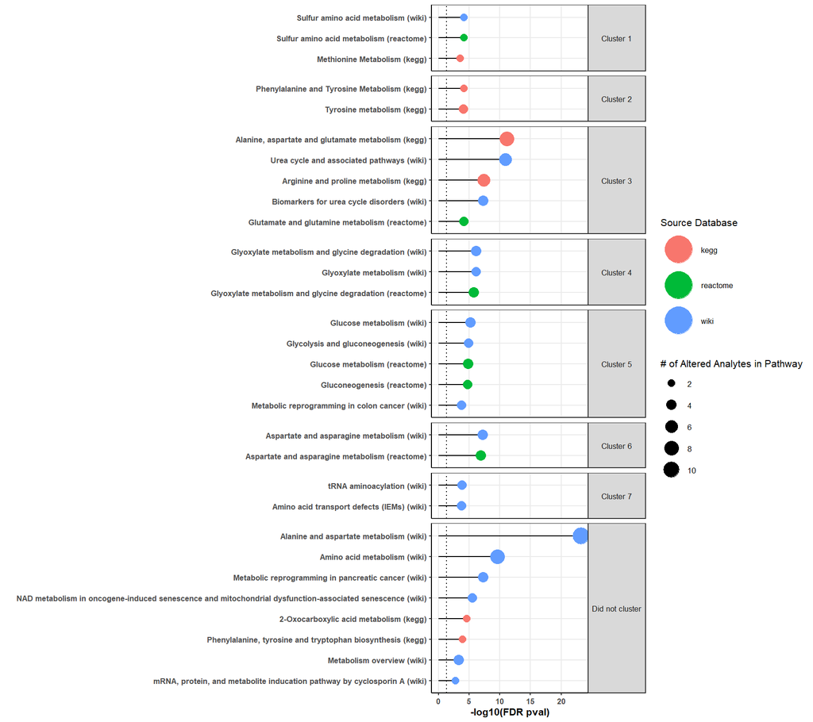

```r
pathwayResultsPlot(db = rampDB, filtered.fisher.results, text_size = 8, perc_analyte_overlap = 0.2,
    min_pathway_tocluster = 2, perc_pathway_overlap = 0.2, interactive = FALSE)
```

### Perform Chemical Enrichment

After retrieving chemical classes of metabolites, the function chemicalClassEnrichment() function will perform overrepresentation analysis using a Fisher’s test and output classes that show enrichment in the user input list of metabolites relative to the backgroud metabolite population (all meteabolites in RaMP). The function performs enrichment analysis for Classyfire classes, sub-classess, and super-classes, and for LipidMaps categories, main classess, and sub classes.

```r
metabolites.of.interest = c('hmdb:HMDB0000056','hmdb:HMDB0000439','hmdb:HMDB0000479','hmdb:HMDB0000532',
                            'hmdb:HMDB0001015','hmdb:HMDB0001138','hmdb:HMDB0029159','hmdb:HMDB0029412',
                            'hmdb:HMDB0034365','hmdb:HMDB0035227','hmdb:HMDB0007973','hmdb:HMDB0008057',
                            'hmdb:HMDB0011211')
chemical.enrichment <- chemicalClassEnrichment(db = rampDB, mets = metabolites.of.interest)
```

```
## [1] "Starting Chemical Class Enrichment"
## [1] "Starting Chemical Class Survey"
## [1] "...finished metabolite list query..."
## [1] "...finished DB population query..."
## [1] "...collating data..."
## [1] "...creating query efficiency summary..."
## [1] "Finished Chemical Class Survey"
## [1] "check total summary"
## [1] "getting population totals"
## [1] "Finished Chemical Class Enrichment"
```

```r
# Enrichment was performed on the following chemical classes:
names(chemical.enrichment)
```

```
## [1] "ClassyFire_class"       "ClassyFire_sub_class"   "ClassyFire_super_class"
## [4] "result_type"
```

```r
# To retrieve results for the ClassyFire Class:
classy_fire_classes <- chemical.enrichment$ClassyFire_class
datatable(classy_fire_classes)
```

|  | category | class_name | met_hits | pop_hits | met_size | pop_size | p-value | adjP_BH |
| --- | --- | --- | --- | --- | --- | --- | --- | --- |
| 2 | ClassyFire_class | Carboxylic acids and derivatives | 10 | 4270 | 13 | 145833 | 1.208602635900279e-13 | 2.417205271800558e-13 |
| 1 | ClassyFire_class | Glycerophospholipids | 3 | 62689 | 13 | 145833 | 0.9629183164121264 | 0.9629183164121264 |

*Note*: To explicitly view the results of mapping input IDs to RaMP, users can run the chemicalClassSurvey() function as noted in above in the section “Retrieve Chemical Class from Input Metabolites”.

This code section demonstrates a Rhea reaction query.

```r
analytes.of.interest <- c('chebi:57368', 'uniprot:Q96N66', 'CHEBI:73003')

reactionsLists <- RaMP::getReactionsForAnalytes(db = rampDB, analytes = analytes.of.interest, includeTransportRxns = F, humanProtein = T)
```

```
## [1] "Retrieving reactions for compounds"
## [1] "Retrieving reactions for genes/proteins"
```

```r
# just show the reactions with at least one metabolite and one protein in commmon.
datatable(subset(reactionsLists$metProteinCommonReactions, select = -c(rxn_html_label)))
```

|  | metabolites | met_names | genes | uniprot | proteinNames | reactionId | rxn_dir | rxn_label | is_transport | has_human_protein | only_human_mets |
| --- | --- | --- | --- | --- | --- | --- | --- | --- | --- | --- | --- |
| 1 | chebi:57368 | (5Z,8Z,11Z,14Z)-eicosatetraenoyl-CoA | uniprot:Q96N66 | uniprot:Q96N66 | MBOAT7 | rhea:35999 | UN | (5Z,8Z,11Z,14Z)-eicosatetraenoyl-CoA + 1-hexadecanoyl-sn-glycero-3-phosphocholine = 1-hexadecanoyl-2-(5Z,8Z,11Z,14Z-eicosatetraenoyl)-sn-glycero-3-phosphocholine + CoA | 0 | 1 | 1 |
| 2 | chebi:57368 | (5Z,8Z,11Z,14Z)-eicosatetraenoyl-CoA | uniprot:Q96N66 | uniprot:Q96N66 | MBOAT7 | rhea:36835 | UN | (5Z,8Z,11Z,14Z)-eicosatetraenoyl-CoA + 1-octadecanoyl-sn-glycero-3-phospho-(1D-myo-inositol) = 1-octadecanoyl-2-(5Z,8Z,11Z,14Z-eicosatetraenoyl)-sn-glycero-3-phospho-(1D-myo-inositol) + CoA | 0 | 1 | 0 |
| 3 | chebi:57368 | (5Z,8Z,11Z,14Z)-eicosatetraenoyl-CoA | uniprot:Q96N66 | uniprot:Q96N66 | MBOAT7 | rhea:37015 | UN | (5Z,8Z,11Z,14Z)-eicosatetraenoyl-CoA + a 1-acyl-sn-glycero-3-phospho-(1D-myo-inositol) = a 1-acyl-2-(5Z,8Z,11Z,14Z-eicosatetraenoyl)-sn-glycero-3-phospho-(1D-myo-inositol) + CoA | 0 | 1 | 0 |

Three reaction lists are returned, metabolites-to-reactions, proteins-to-reactions, and reactions that have at least one metaboite and one protein from the input analyte list.